# Assignment 1 - Statistical Models

# 1 Exercise 2

Whenever appropriate, use relevant diagnostic tools to check the model assumptions.

A hardness testing machine operates by pressing a tip into a metal test “coupon”. The hardness of the coupon can be determined from the depth of the resulting depression. Four tip types are being tested to see if they produce significantly different readings. The coupons might differ slightly in their hardness (for example, if they are taken from ingots produced in different heats). Thus coupon is a nuisance factor, which should in principle be taken into account. Such type of analysis (combination of factor(s) of importance and block factor(s) to be taken into account) is called randomized block design.

## 1.1 a

Suppose you were to set up this experiment: propose an R-function which creates a random order of 16 tests covering all the combinations of levels of the two factors in a randomized block design.

```r
# Function to create randomized block design
randomized_block_design <- function(tips, coupons) {

  # Ensure reproducibility
  set.seed(123)

  # Initialize a data frame to store the randomized block design
  design <- data.frame(Coupon = rep(coupons, each = length(tips)),
                       Tip = rep(tips, times = length(coupons)),
                       RandomOrder = NA)

  for (i in 1:length(coupons)) {
    design$RandomOrder[design$Coupon == coupons[i]] <- sample(1:length(tips))
  }

  return(design)
}

# Define the tips and coupons
tips <- 1:4           # 4 types of tips
coupons <- 1:4        # 4 coupons (blocks)

# Generate the randomized block design
df <- randomized_block_design(tips, coupons)

# Add the hardness values from the table
hardness_values <- c(9.3, 9.4, 9.2, 9.7,
                     9.4, 9.3, 9.4, 9.6,
                     9.6, 9.8, 9.5, 10.0,
                     10.0, 9.9, 9.7, 10.2)

# Add the hardness values as a new column in df
df$Hardness <- hardness_values
df
```

```
##    Coupon Tip RandomOrder Hardness
## 1       1   1           3      9.3
## 2       1   2           4      9.4
## 3       1   3           1      9.2
## 4       1   4           2      9.7
## 5       2   1           3      9.4
## 6       2   2           2      9.3
## 7       2   3           4      9.4
## 8       2   4           1      9.6
## 9       3   1           3      9.6
## 10      3   2           1      9.8
## 11      3   3           2      9.5
## 12      3   4           4     10.0
## 13      4   1           2     10.0
## 14      4   2           1      9.9
## 15      4   3           4      9.7
## 16      4   4           3     10.2
```

## 1.2 b

Make some graphical summaries of the data and give some tentative comments. What can you say about eventual interaction between Coupon and Tip?

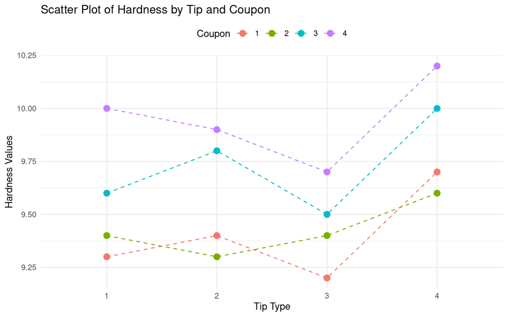

```r
# Load necessary library
library(ggplot2)

# Create a scatter plot
ggplot(df, aes(x = factor(Tip), y = Hardness, color = factor(Coupon))) +
  geom_point(size = 3) +   # Add points
  geom_line(aes(group = Coupon), linetype = "dashed") + # Connect points with dashed lines
  labs(title = "Scatter Plot of Hardness by Tip and Coupon",
       x = "Tip Type",
       y = "Hardness Values",
       color = "Coupon") +
  theme_minimal() +
  theme(legend.position = "top")
```

The lines connecting the points are not parallel. This suggests that there is a potential interaction effect between the Coupon and the Tip. Specifically, the effectiveness of the tips differs depending on which coupon they are paired with. For instance, Tip 4 seems to perform significantly better with Coupon 3 and Coupon 4 compared to Coupon 1 and 2. This indicates that the hardness produced by different tips is influenced by the specific coupon being used.

## 1.3 c

Test the null hypothesis that the hardness is the same for all types of tip.

To test the null hypothesis that the hardness is the same for all tips, we can use a two-way ANOVA with “Coupon” as a blocking factor and “Tip” as the factor of interest.

```r
df$Coupon <- as.factor(df$Coupon)  # Convert Coupon to factor
df$Tip <- as.factor(df$Tip)         # Convert Tip to factor
# Perform ANOVA to test for differences in hardness across tips
anova_mod <- aov(Hardness ~ Tip + Coupon, data = df)
summary(anova_mod)
```

```
##             Df Sum Sq Mean Sq F value   Pr(>F)
## Tip          3  0.385 0.12833   14.44 0.000871 ***
## Coupon       3  0.825 0.27500   30.94 4.52e-05 ***
## Residuals    9  0.080 0.00889
## ---
## Signif. codes:  0 '***' 0.001 '**' 0.01 '*' 0.05 '.' 0.1 ' ' 1
```

Since the p-value of Tip = 0.000871 $<$ 0.05, we reject the null hypothesis that the hardness is the same for all types of tips. This indicates that there are significant differences in hardness among at least some of the different tips tested.

## 1.4 d

Which type of tip is preferable? How does the hardness depend on the type coupon? Estimate the hardness of coupon of type 3 one uses a tip of type 2, do the same for coupon of type 1 and a tip of type 4.

The mean hardness values calculated will give us insight into which tip is preferable. The tip with the highest mean hardness across all coupons would generally be considered the best option.

```r
mean_hardness <- aggregate(Hardness ~ Tip, data = df, FUN = mean)
print(mean_hardness)
```

```
##   Tip Hardness
## 1   1    9.575
## 2   2    9.600
## 3   3    9.450
## 4   4    9.875
```

Tip 4 has the highest mean of hardness, hence, it is the most preferable.

```r
predict(anova_mod, df2 = data.frame(Tip = 2, Coupon = 3))  # Tip 2, Coupon 3
```

```
##      1      2      3      4      5      6      7      8      9     10     11
##  9.350  9.375  9.225  9.650  9.375  9.400  9.250  9.675  9.675  9.700  9.550
##     12     13     14     15     16
##  9.975  9.900  9.925  9.775 10.200
```

```r
predict(anova_mod, df2 = data.frame(Tip = 4, Coupon = 1))  # Tip 4, Coupon 1
```

```
##      1      2      3      4      5      6      7      8      9     10     11
##  9.350  9.375  9.225  9.650  9.375  9.400  9.250  9.675  9.675  9.700  9.550
##     12     13     14     15     16
##  9.975  9.900  9.925  9.775 10.200
```

## 1.5 e

Test the null hypothesis that the hardness is the same for all types of tip, now ignoring the variable Coupon. Is it right/wrong and useful/not useful to perform this test on this dataset?

To ignore the “Coupon” factor, we will perform a one-way ANOVA:

```r
anova_mod2 <- aov(Hardness ~ Tip, data = df)
summary(anova_mod2)
```

```
##             Df Sum Sq Mean Sq F value Pr(>F)
## Tip          3  0.385 0.12833   1.702   0.22
## Residuals   12  0.905 0.07542
```

# 2 Exercise 3

In each of the three counties in Iowa, a sample of farm was taken from farms for which landlornd and tenant are related and also from farms for which landlord and tenant are not related. The data is contained in data frame crops.txt Download crops.txt, where column Crops contains the value of crops, column Size the size of farm, column County the county and column Related reflects the fact whether landlord and tenant related (value “yes”) or no (value “no”). We are primarily interested in investigating the effect of county and relation of landlord and tenant on the crops.